# Gov 2001: Final Exam

Xiner Zhou

# Problem 1: Job Lock with Logistic Regression

```r
setwd("E:/Advanced Quantitative Method-Gary King/Final Exam")
load("employmentdata.rdata") # load data

library(dplyr)
library(ggplot2)
library(stargazer)
library(mvtnorm)
```

## 1.A

**Estimate the probability of voluntarily changing jobs (chjob) for workers with employment-related health insurance (hi) using logistic regression and the following covariates: othhi, an interaction bt hi and othhi, lhwage, winc, nfam, educ, exper, afram. You may use a canned regression routine to answer this question. Report your coefficient estimates and standard errors below.**

```r
fit <- glm(chjob~ hi + othhi + hi*othhi + lhwage +winc + nfam + educ + exper + afram, data=finaldata1, family="binomial")
summary(fit)$coefficients
```

```
##                  Estimate   Std. Error    z value     Pr(>|z|)
## (Intercept)  5.091954e-01 4.159687e-01  1.2241196 2.209071e-01
## hi          -1.388174e+00 1.672587e-01 -8.2995608 1.044970e-16
## othhi       -2.302865e-01 1.823319e-01 -1.2630068 2.065867e-01
## lhwage      -2.618935e-01 1.170948e-01 -2.2365943 2.531287e-02
## winc         2.173381e-06 4.295296e-06  0.5059911 6.128629e-01
## nfam        -6.991606e-02 5.089803e-02 -1.3736496 1.695505e-01
## educ        -1.639882e-02 2.374454e-02 -0.6906355 4.897947e-01
## exper       -3.304092e-02 7.143051e-03 -4.6256033 3.735095e-06
## afram       -7.139557e-02 1.654356e-01 -0.4315610 6.660605e-01
## hi:othhi     4.715960e-01 2.404383e-01  1.9614017 4.983219e-02
```

## 1.B Calculate:

**a) The expected probability of voluntarily changing jobs for a white married man with employer-provided health insurance but no other source of health insurance available, holding all other covariates at their mean values. Report a 95% confidence interval (using simulation) for your estimate.**

```r
# Step1: Simulate M beta's from sampling distribution
# Step2: Choose one value for each explanatory variable
# Step3: Take one simulated beta's, compute pi from the systematic component (This step simulate estimation uncertainty)
# Step4: Draw m times of the outcome variable (1/0) from the stochastic component (Bernoulli) (This step simulate fundamental uncertainty)
# Step5: Average over the fundamental unceratinty by calculating the mean of the m simulations to yield one simulated expected value (probability)
# (To save computation time and improve approximation, use the same simulated beta's for 1.B(a)-(d) and 1.C )

beta <- fit$coefficients
vcov <- vcov(fit)
set.seed(02138)
M<-10000
m<-10000
sim.betas <- rmvnorm(n=M, mean=beta, sigma=vcov)
X <- finaldata1 %>%
     mutate(Intercept=1)%>%
     select(Intercept, hi, othhi, lhwage, winc, nfam, educ, exper, afram) %>%
     mutate(hi=1, othhi=0, afram=0)%>%
     mutate("hi*othhi"=hi*othhi) %>%
     apply(MARGIN=2, FUN=mean)

exp.prob <-rep(NA, M)
for(i in 1:M){
  pi  <- 1/(1+exp(-X%*%sim.betas[i,]))
  exp.prob[i] <- mean(rbinom(n=m,size=1,prob=pi)) #n= number of obs size=number of trials
}

# 95% CI
quantile(exp.prob, c(0.025,0.975))
```

```
##   2.5%  97.5%
## 0.0597 0.0902
```

```r
# Point Estimate
mean(exp.prob)
```

```
## [1] 0.07384807
```

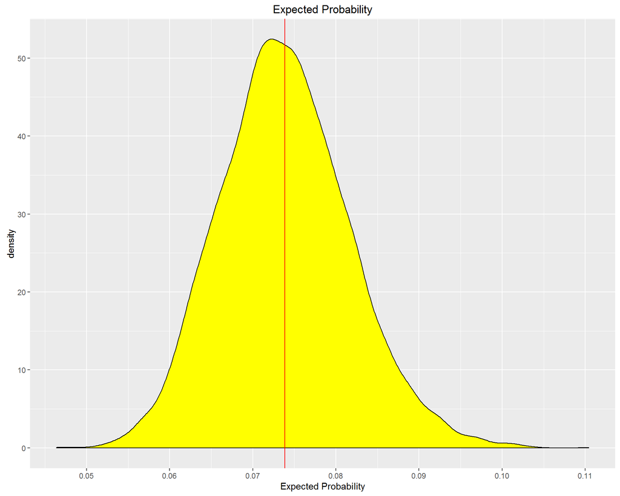

```r
as.data.frame(exp.prob) %>% ggplot(aes(exp.prob)) +
  geom_density(fill="yellow")+
  ggtitle("Expected Probability")+
  xlab("Expected Probability")+
  scale_x_continuous(breaks = seq(0 , max(exp.prob) , 0.01) )+
  geom_vline(xintercept=mean(exp.prob), colour='red')
```

**b) The expected probability of voluntarily changing jobs for a white married man with employer-provided health insurance and other sources of health insurance available, holding all other covariates at their mean values. Report a 95% confidence interval (using simulation) for your estimate.**

```r
X <- finaldata1 %>%
  mutate(Intercept=1)%>%
  select(Intercept, hi, othhi, lhwage, winc, nfam, educ, exper, afram) %>%
  mutate(hi=1, othhi=1, afram=0)%>%
  mutate("hi*othhi"=hi*othhi) %>%
  apply(MARGIN=2, FUN=mean)

exp.prob <-rep(NA, M)
for(i in 1:M){
  pi  <- 1/(1+exp(-X%*%sim.betas[i,]))
  exp.prob[i] <- mean(rbinom(n=m,size=1,prob=pi)) #n= number of obs size=number of trials
}

# 95% CI
quantile(exp.prob, c(0.025,0.975))
```

```
##      2.5%     97.5%
## 0.0720000 0.1162025
```

```r
# Point Estimate
mean(exp.prob)
```

```
## [1] 0.09220491
```

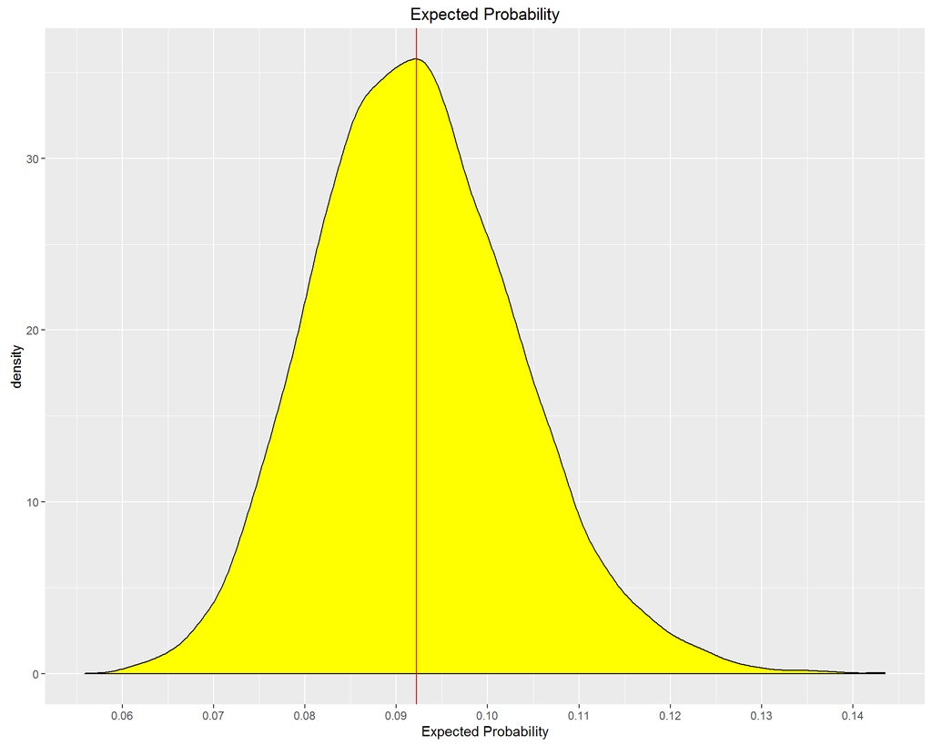

```r
as.data.frame(exp.prob) %>% ggplot(aes(exp.prob)) +
  geom_density(fill="yellow")+
  ggtitle("Expected Probability")+
  xlab("Expected Probability")+
  scale_x_continuous(breaks = seq(0 , max(exp.prob) , 0.01) )+
  geom_vline(xintercept=mean(exp.prob), colour='red')
```

**c) The expected probability of voluntarily changing jobs for a white married man without employer-provided health insurance and no other sources of health insurance available, holding all other covariates at their mean values. Report a 95% confidence interval (using simulation) for your estimate.**

```r
X <- finaldata1 %>%
  mutate(Intercept=1)%>%
  select(Intercept, hi, othhi, lhwage, winc, nfam, educ, exper, afram) %>%
  mutate(hi=0, othhi=0, afram=0)%>%
  mutate("hi*othhi"=hi*othhi) %>%
  apply(MARGIN=2, FUN=mean)

exp.prob <-rep(NA, M)
for(i in 1:M){
  pi  <- 1/(1+exp(-X%*%sim.betas[i,]))
  exp.prob[i] <- mean(rbinom(n=m,size=1,prob=pi)) #n= number of obs size=number of trials
}

# 95% CI
quantile(exp.prob, c(0.025,0.975))
```

```
##   2.5%  97.5%
## 0.1968 0.2931
```

```r
# Point Estimate
mean(exp.prob)
```

```
## [1] 0.2424771
```

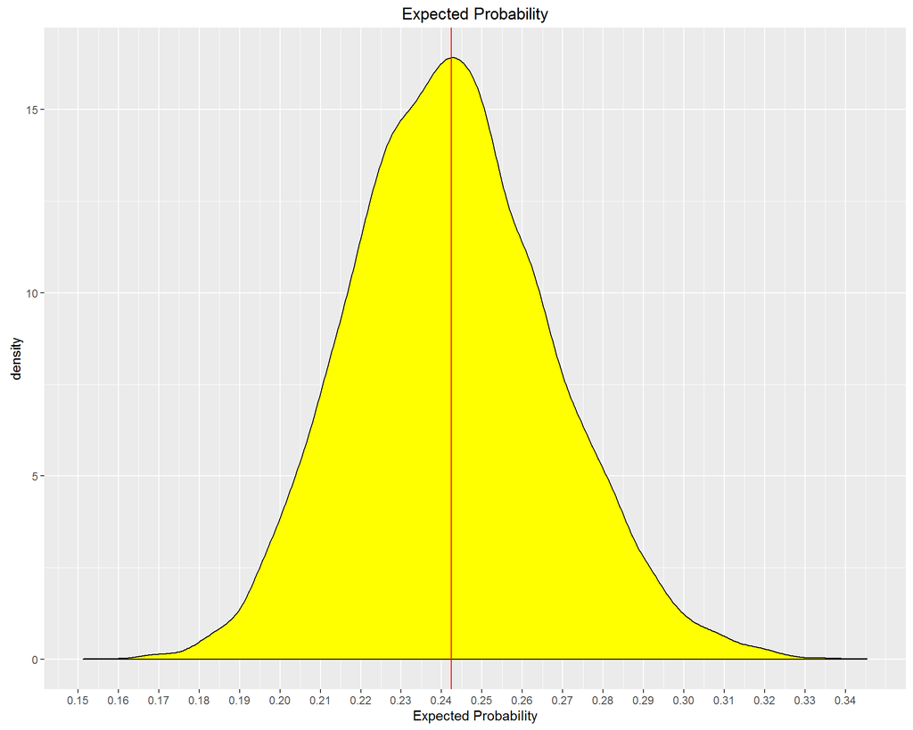

```r
as.data.frame(exp.prob) %>% ggplot(aes(exp.prob)) +
  geom_density(fill="yellow")+
  ggtitle("Expected Probability")+
  xlab("Expected Probability")+
  scale_x_continuous(breaks = seq(0 , max(exp.prob) , 0.01) )+
  geom_vline(xintercept=mean(exp.prob), colour='red')
```

**d) The expected probability of voluntarily changing jobs for a white married man without employer-provided health insurance but other sources of health insurance available, holding all other covariates at their mean values. Report a 95% confidence interval (using simulation) for your estimate.**

```r
X <- finaldata1 %>%
  mutate(Intercept=1)%>%
  select(Intercept, hi, othhi, lhwage, winc, nfam, educ, exper, afram) %>%
  mutate(hi=0, othhi=1, afram=0)%>%
  mutate("hi*othhi"=hi*othhi) %>%
  apply(MARGIN=2, FUN=mean)

exp.prob <-rep(NA, M)
for(i in 1:M){
  pi  <- 1/(1+exp(-X%*%sim.betas[i,]))
  exp.prob[i] <- mean(rbinom(n=m,size=1,prob=pi)) #n= number of obs size=number of trials
}

# 95% CI
quantile(exp.prob, c(0.025,0.975))
```

```
##   2.5%  97.5%
## 0.1621 0.2477
```

```r
# Point Estimate
mean(exp.prob)
```

```
## [1] 0.20203
```

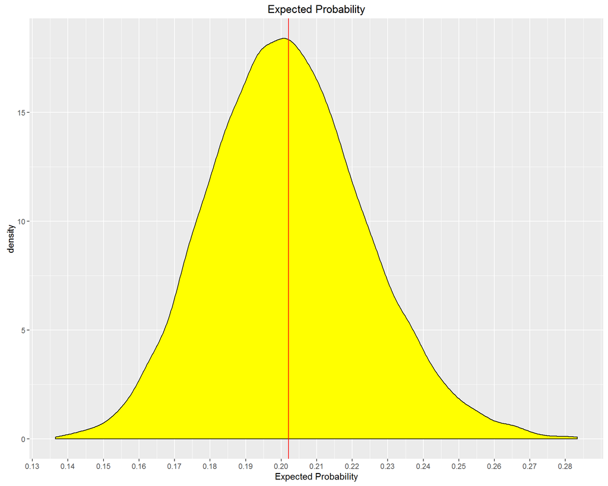

```r
as.data.frame(exp.prob) %>% ggplot(aes(exp.prob)) +
  geom_density(fill="yellow")+
  ggtitle("Expected Probability")+
  xlab("Expected Probability")+
  scale_x_continuous(breaks = seq(0 , max(exp.prob) , 0.01) )+
  geom_vline(xintercept=mean(exp.prob), colour='red')
```

## 1.C Calculate:

**a) The expected difference in probability of voluntarily changing jobs between a white married man with employer-provided health insurance, but no other coverage and a white married man without employer-provided health insurance and no other coverage, holding all other covariates at their mean values. Report a 95% confidence interval (using simulation) for your estimate.**

```r
# Take the difference in the expected probabilities
X1 <- finaldata1 %>%
  mutate(Intercept=1)%>%
  select(Intercept, hi, othhi, lhwage, winc, nfam, educ, exper, afram) %>%
  mutate(hi=1, othhi=0, afram=0)%>%
  mutate("hi*othhi"=hi*othhi) %>%
  apply(MARGIN=2, FUN=mean)

X0 <- finaldata1 %>%
  mutate(Intercept=1)%>%
  select(Intercept, hi, othhi, lhwage, winc, nfam, educ, exper, afram) %>%
  mutate(hi=0, othhi=0, afram=0)%>%
  mutate("hi*othhi"=hi*othhi) %>%
  apply(MARGIN=2, FUN=mean)

first.diff <-rep(NA, M)
for(i in 1:M){
  pi.1  <- 1/(1+exp(-X1%*%sim.betas[i,]))
  pi.0  <- 1/(1+exp(-X0%*%sim.betas[i,]))
  first.diff[i] <- mean(rbinom(n=m,size=1,prob=pi.1))-mean(rbinom(n=m,size=1,prob=pi.0))
}

# 95% CI
quantile(first.diff, c(0.025, 0.975))
```

```
##       2.5%      97.5%
## -0.2215025 -0.1210975
```

```r
# Point Estimate
mean(first.diff)
```

```
## [1] -0.1686883
```

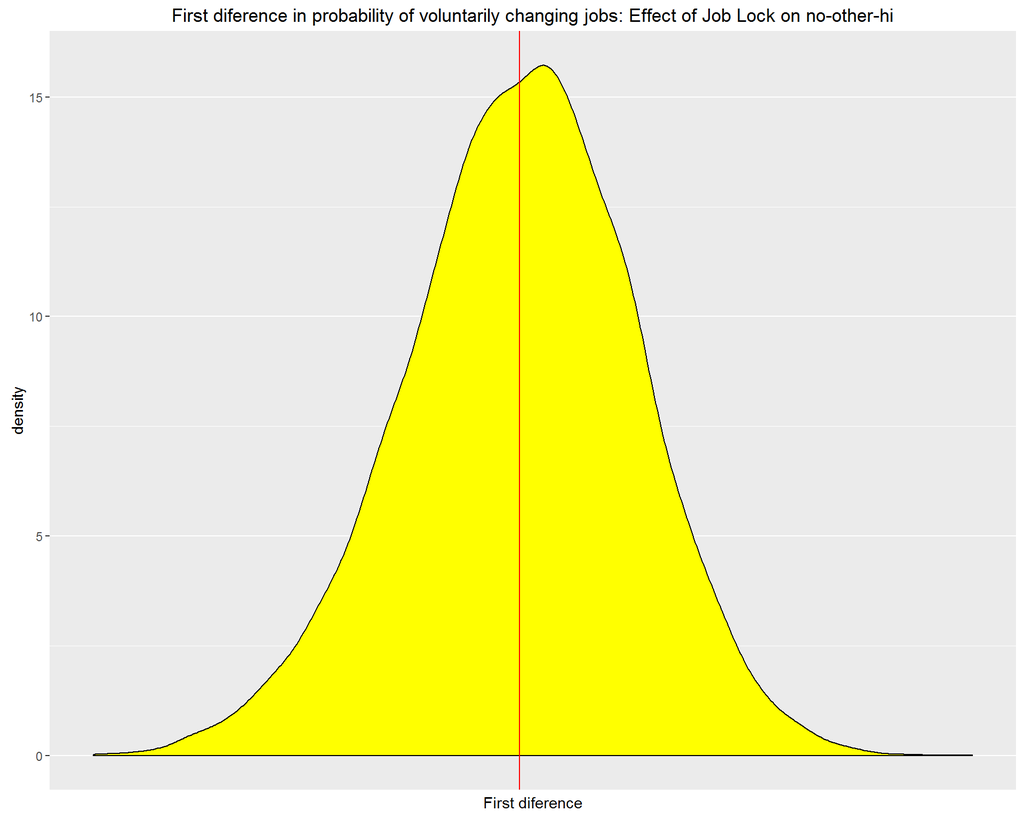

```r
as.data.frame(first.diff) %>% ggplot(aes(first.diff)) +
  geom_density(fill="yellow")+
  ggtitle("First diference in probability of voluntarily changing jobs: Effect of Job Lock on no-other-hi")+
  xlab("First diference")+
  scale_x_continuous(breaks = seq(0 , max(exp.prob) , 0.01) )+
  geom_vline(xintercept=mean(first.diff), colour='red')
```

**b) The expected diference in probability of voluntarily changing jobs between a white married man without employer-provided health insurance and no other coverage and a white married man without employer-provided health insurance, but with other coverage holding all other covariates at their mean values. Report a 95% confidence interval (using simulation) for your estimate.**

```r
# Take the difference in the expected probabilities
X1 <- finaldata1 %>%
  mutate(Intercept=1)%>%
  select(Intercept, hi, othhi, lhwage, winc, nfam, educ, exper, afram) %>%
  mutate(hi=0, othhi=0, afram=0)%>%
  mutate("hi*othhi"=hi*othhi) %>%
  apply(MARGIN=2, FUN=mean)

X0 <- finaldata1 %>%
  mutate(Intercept=1)%>%
  select(Intercept, hi, othhi, lhwage, winc, nfam, educ, exper, afram) %>%
  mutate(hi=0, othhi=1, afram=0)%>%
  mutate("hi*othhi"=hi*othhi) %>%
  apply(MARGIN=2, FUN=mean)

first.diff <-rep(NA, M)
for(i in 1:M){
  pi.1  <- 1/(1+exp(-X1%*%sim.betas[i,]))
  pi.0  <- 1/(1+exp(-X0%*%sim.betas[i,]))
  first.diff[i] <- mean(rbinom(n=m,size=1,prob=pi.0))-mean(rbinom(n=m,size=1,prob=pi.1))
}

# 95% CI
quantile(first.diff, c(0.025, 0.975))
```

```
##       2.5%      97.5%
## -0.1038050  0.0213025
```

```r
mean(first.diff)
```

```
## [1] -0.04036327
```

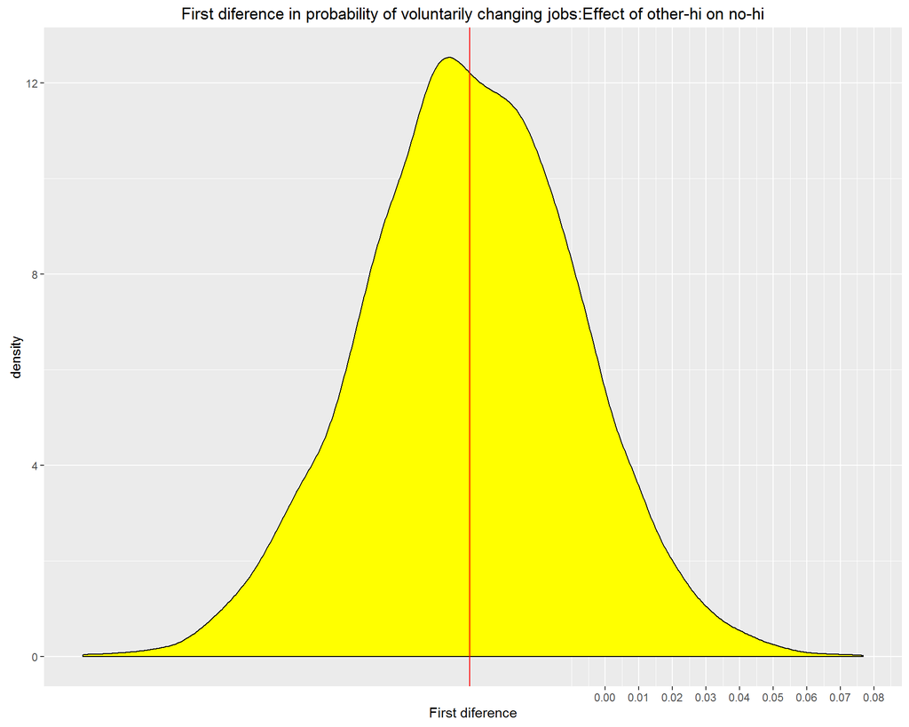

```r
as.data.frame(first.diff) %>% ggplot(aes(first.diff)) +
  geom_density(fill="yellow")+
  ggtitle("First diference in probability of voluntarily changing jobs:Effect of other-hi on no-hi")+
  xlab("First diference")+
  scale_x_continuous(breaks = seq(0 , max(exp.prob) , 0.01) )+
  geom_vline(xintercept=mean(first.diff), colour='red')
```

## 1.D

**What do the results from 1.B and 1.C reveal about the existence or non-existence of job lock? How does having employer-provided heath insurance affect the probability of voluntarily changing jobs? How does having other sources of insurance moderate that relationship? Is this consistent with the job lock hypothesis?**

> Therefore, job lock indeed exists, employees are less likely to seek new employment opportunities if employer provide health insurance, regardless of whether they had other insurance coverage, and all other socio-economic factors we have adjusted. However, having other sources of health insurance does moderate this relationship, it weakens the effect of job lock, the average effect of job lock shrinks from a 16.86% reduction to 10.98% reduction. It makes sense because employees with other sources of insurance tends to less worry about losing employer-provided health insurance simply because they have backup plans, thus job is less a constrain (but still is a constrain) or factor when considering new employment opportunities.

```r
# compare results from 1B.b with 1B.d
X1 <- finaldata1 %>%
  mutate(Intercept=1)%>%
  select(Intercept, hi, othhi, lhwage, winc, nfam, educ, exper, afram) %>%
  mutate(hi=1, othhi=1, afram=0)%>%
  mutate("hi*othhi"=hi*othhi) %>%
  apply(MARGIN=2, FUN=mean)

X0 <- finaldata1 %>%
  mutate(Intercept=1)%>%
  select(Intercept, hi, othhi, lhwage, winc, nfam, educ, exper, afram) %>%
  mutate(hi=0, othhi=1, afram=0)%>%
  mutate("hi*othhi"=hi*othhi) %>%
  apply(MARGIN=2, FUN=mean)

first.diff <-rep(NA, M)
for(i in 1:M){
  pi.1  <- 1/(1+exp(-X1%*%sim.betas[i,]))
  pi.0  <- 1/(1+exp(-X0%*%sim.betas[i,]))
  first.diff[i] <- mean(rbinom(n=m,size=1,prob=pi.1))-mean(rbinom(n=m,size=1,prob=pi.0))
}

# 95% CI
quantile(first.diff, c(0.025, 0.975))
```

```
##      2.5%     97.5%
## -0.157400 -0.065995
```

```r
mean(first.diff)
```

```
## [1] -0.1098288
```

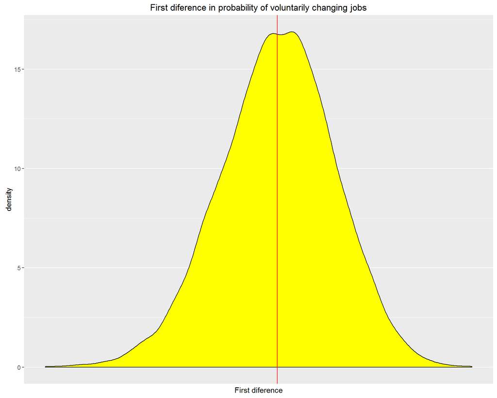

```r
as.data.frame(first.diff) %>% ggplot(aes(first.diff)) +
  geom_density(fill="yellow")+
  ggtitle("First diference in probability of voluntarily changing jobs")+
  xlab("First diference")+
  scale_x_continuous(breaks = seq(0 , max(exp.prob) , 0.01) )+
  geom_vline(xintercept=mean(first.diff), colour='red')
```

# Problem 2: Tobit Regression

## 2.B

**Write a function in R that evaluates the log-likelihood.**

```r
tobit.ll <- function(par, outcome, covariates, indicator, c) {

  # check to see if the first column is all 1's
  # if not, add 1's for the intercept column
  if(!all(covariates[,1]==1)){covariates<-as.matrix(cbind(1,covariates))}

  xb <-covariates %*% par[-length(par)]
  sigma  <- sqrt(exp(par[length(par)])) # last parameter is log(sigma^2)

  # if observed that is yi>c
  p1 <-dnorm(outcome, mean = xb, sd = sigma , log=TRUE )
  # if censored tht is yi<=c
  p0 <-pnorm(c, mean = xb, sd = sigma , lower.tail = TRUE, log.p =TRUE)
  # log-likelihood
  sum(indicator*p1+(1-indicator)*p0)

}
```

## 2.C

**Using your log-likelihood function and optim(), run a tobit regression where durable is the dependent variable and age and quant are the independent variables. In this case, the dependent variable is censored at c = 0. Report estimates and standard errors for the beta’s and report an estimate of sigma in a table. Do not use a canned tobit routine for this part.**

```r
library(Zelig)
data(tobin)

# create X matrix
X<-as.matrix(cbind(1,select(tobin, age, quant)))
c<-0
d<-ifelse(tobin$durable>c,1,0)
MLE <- optim(par=rep(1,ncol(X)+1),
             fn=tobit.ll,
             covariates=X,
             outcome=tobin$durable,
             indicator=d,
             c=c,
             control=list(fnscale=-1, maxit=1000),
             hessian = T,
             method = "BFGS")

# MLE coefficient estimates are:
Effect <-MLE$par
Effect[length(Effect)] <-sqrt(exp(Effect[length(Effect)])) # last parameter is log(sigma^2)
# MLE standard errors are:
## observed fisher information
obs_fisher_info <- -MLE$hessian
## variance-covariance matrix
vcov <-solve(obs_fisher_info)
SE <-sqrt(diag(vcov))
SE[length(SE)] <-sqrt(exp(SE[length(SE)])) # last parameter is log(sigma^2)
## Vaiable names
Variable <- c("Intercept",
              "age",
              "quant",
              "sigma")
## Put into a data frame
MLE.table<-data.frame(Variable, Effect, SE)
MLE.table
```

```
##    Variable      Effect          SE
## 1 Intercept 15.18913808 16.09258595
## 2       age -0.12918265  0.21878273
## 3     quant -0.04571148  0.05830565
## 4     sigma  5.57693949  1.36410958
```

```r
# check results
fit1<- zelig(durable ~ age+quant, below = 0, above = Inf, model="tobit", data = tobin)
```

```
## How to cite this model in Zelig:
##   Christian Kleiber, and Achim Zeileis. 2011.
##   tobit: Linear regression for Left-Censored Dependent Variable
##   in Christine Choirat, James Honaker, Kosuke Imai, Gary King, and Olivia Lau,
##   "Zelig: Everyone's Statistical Software," http://zeligproject.org/
```

```r
summary(fit1)# Correct!!!
```

```
## Model:
##
## Call:
## z5$zelig(formula = durable ~ age + quant, below = 0, above = Inf,
##     data = tobin)
##
## Observations:
##          Total  Left-censored     Uncensored Right-censored
##             20             13              7              0
##
## Coefficients:
##             Estimate Std. Error z value Pr(>|z|)
## (Intercept) 15.14487   16.07945   0.942    0.346
## age         -0.12906    0.21858  -0.590    0.555
## quant       -0.04554    0.05825  -0.782    0.434
## Log(scale)   1.71785    0.31032   5.536  3.1e-08
##
## Scale: 5.573
##
## Gaussian distribution
## Number of Newton-Raphson Iterations: 3
## Log-likelihood: -28.94 on 4 Df
## Wald-statistic: 1.124 on 2 Df, p-value: 0.57002
##
## Next step: Use 'setx' method
```

```r
library(AER)
fit2<-tobit(durable ~ age+quant, left = 0, right = Inf, dist = "gaussian", data = tobin)
summary(fit2)# Correct!!!
```

```
##
## Call:
## tobit(formula = durable ~ age + quant, left = 0, right = Inf,
##     dist = "gaussian", data = tobin)
##
## Observations:
##          Total  Left-censored     Uncensored Right-censored
##             20             13              7              0
##
## Coefficients:
##             Estimate Std. Error z value Pr(>|z|)
## (Intercept) 15.14487   16.07945   0.942    0.346
## age         -0.12906    0.21858  -0.590    0.555
## quant       -0.04554    0.05825  -0.782    0.434
## Log(scale)   1.71785    0.31032   5.536  3.1e-08 ***
## ---
## Signif. codes:  0 '***' 0.001 '**' 0.01 '*' 0.05 '.' 0.1 ' ' 1
##
## Scale: 5.573
##
## Gaussian distribution
## Number of Newton-Raphson Iterations: 3
## Log-likelihood: -28.94 on 4 Df
## Wald-statistic: 1.124 on 2 Df, p-value: 0.57002
```

## 2.D

**Generate a histogram of 10,000 expected values of Y_i with quant at it’s 20th percentile value and age at its mean. Set your seed to 12345 and do not set the seed again for the rest of Problem 2.**

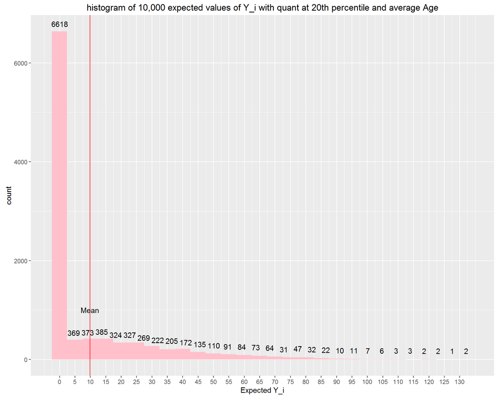

```r
# Step1: Simulate M beta's from sampling distribution
# Step2: Choose one value for each explanatory variable
# Step3: Take one simulated beta's, compute mu and sigma from the systematic component (This step simulate estimation uncertainty)
# Step4: Draw m times of the latent outcome variable from the stochastic component (Normal distribution) (This step simulate fundamental uncertainty)
# Step5: Average over the fundamental unceratinty by calculating the mean of the m simulations to yield one simulated expected value of latent variable Y_i*
# Step6: Our quantity of interest is the left-censored dependent variable Y_i, if Y_i* >0 then expected Y_i=Y_i*; if Y_i*<=0 then Y_i=0
# (To save computation time and improve approximation, use the same simulated beta's for 1.B(a)-(d) and 1.C )

set.seed(12345)
M<-10000
m<-10000
beta <-MLE$par
vcov <-solve(-MLE$hessian)
sim.betas <- rmvnorm(n=M, mean=beta, sigma=vcov) # last column is unbounded log(sigma^2)

X<-tobin%>% summarise(Intercept=1,quant=quantile(quant,0.2), age=mean(age))%>%as.matrix()

exp.Y  <-rep(NA, M)
for(i in 1:M){

  mu <- X%*%sim.betas[i,-ncol(sim.betas)]
  sigma <-sqrt(exp(sim.betas[i,ncol(sim.betas)]))
  # draw latent dependent variable Y_i* from N(mu, sigma2), m=10000 times and then average away fundamental uncertainty
  # if expected Y_i*>0 then expected Y_i=Y_i*, otherwise expected Y_i=c=0
  exp.Y[i]<-ifelse(mean(rnorm(n=m, mean=mu, sd=sigma))>0,mean(rnorm(n=m, mean=mu, sd=sigma)), 0)

}

as.data.frame(exp.Y) %>% ggplot(aes(exp.Y)) +
  geom_histogram(fill="pink",binwidth=5)+
  ggtitle("histogram of 10,000 expected values of Y_i with quant at 20th percentile and average Age")+
  xlab("Expected Y_i") +
  geom_vline(xintercept=mean(exp.Y), colour='red')+
  stat_bin(geom="text", aes(label=..count..) , vjust = -1) +
  scale_x_continuous(breaks = seq(0 , max(exp.Y) , 5 ) )+
  annotate("text", x = mean(exp.Y), y = 1000, label = "Mean")
```

```r
quantile(exp.Y, c(0.025,0.5,0.975))
```

```
##     2.5%      50%    97.5%
##  0.00000  0.00000 65.58297
```

## 2.E

**Generate a histogram of 10,000 expected values with quant at it’s 80th percentile value and age at its mean.**

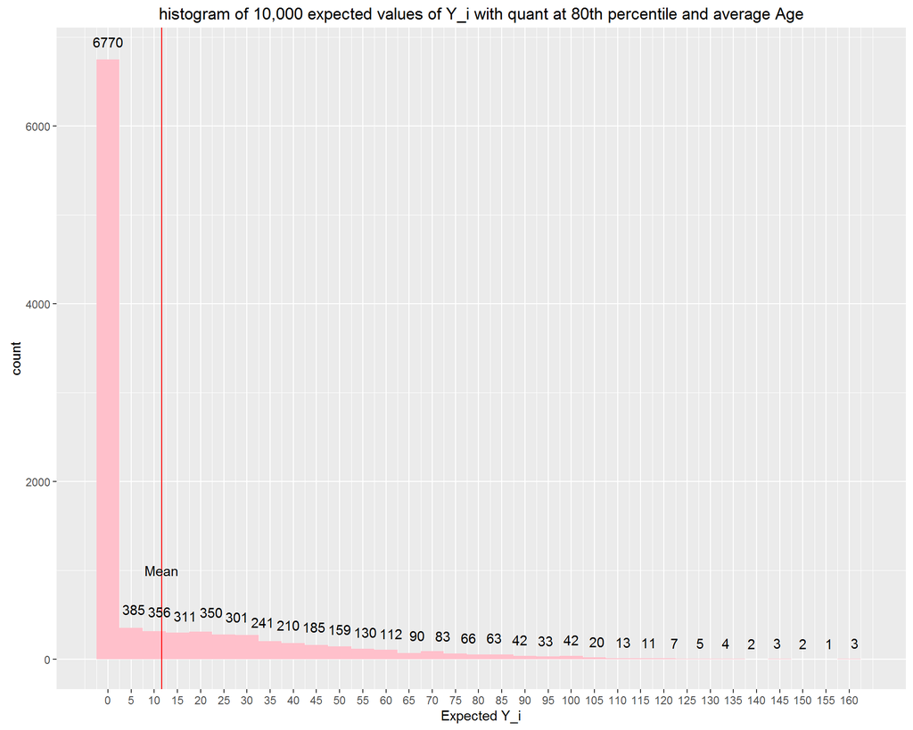

```r
X<-tobin%>% summarise(Intercept=1,quant=quantile(quant,0.8), age=mean(age))%>%as.matrix()

exp.Y  <-rep(NA, M)
for(i in 1:M){

  mu <- X%*%sim.betas[i,-ncol(sim.betas)]
  sigma <-sqrt(exp(sim.betas[i,ncol(sim.betas)]))
  # draw latent dependent variable Y_i* from N(mu, sigma2), m=10000 times and then average away fundamental uncertainty
  # if expected Y_i*>0 then expected Y_i=Y_i*, otherwise expected Y_i=c=0
  exp.Y[i]<-ifelse(mean(rnorm(n=m, mean=mu, sd=sigma))>0,mean(rnorm(n=m, mean=mu, sd=sigma)), 0)

}

as.data.frame(exp.Y) %>% ggplot(aes(exp.Y)) +
  geom_histogram(fill="pink",binwidth=5)+
  ggtitle("histogram of 10,000 expected values of Y_i with quant at 80th percentile and average Age")+
  xlab("Expected Y_i") +
  geom_vline(xintercept=mean(exp.Y), colour='red')+
  stat_bin(geom="text", aes(label=..count..) , vjust = -1) +
  scale_x_continuous(breaks = seq(0 , max(exp.Y) , 5 ) )+
  annotate("text", x = mean(exp.Y), y = 1000, label = "Mean")
```

```r
quantile(exp.Y, c(0.025,0.5,0.975))
```

```
##    2.5%     50%   97.5%
##  0.0000  0.0000 80.5658
```

## 2.F

**Setting age at its mean, generate histogram of 10,000 first differences going from the 20th percentile of quant to the 80th percentile of quant. (Note: You should draw your sigma parameter on the log (unbounded) scale when drawing the simulated parameters)**

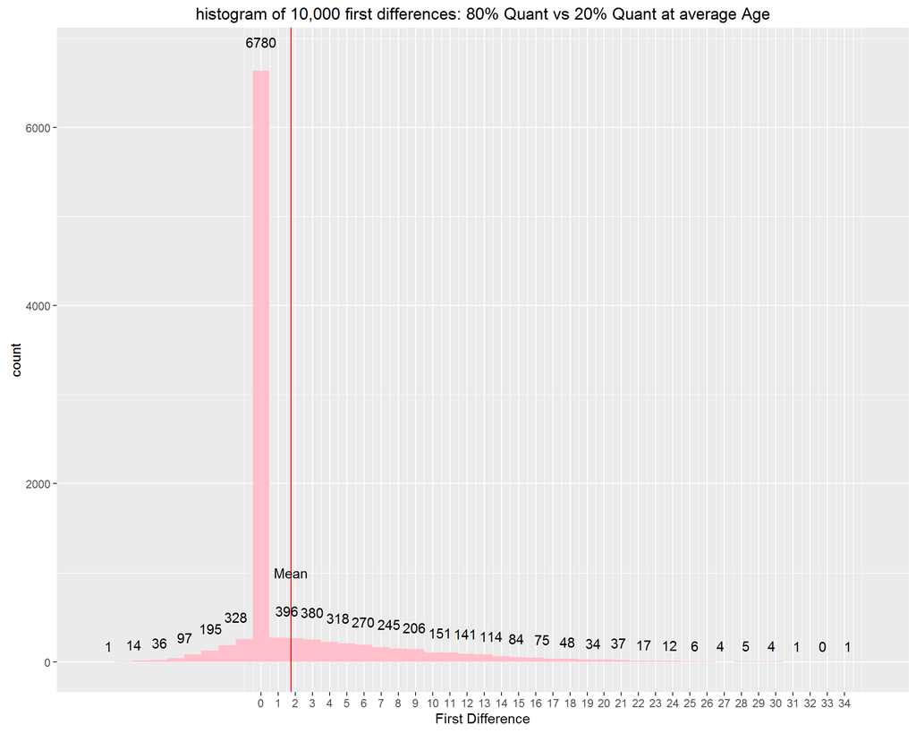

```r
X1<-tobin%>% summarise(Intercept=1,quant=quantile(quant,0.8), age=mean(age))%>%as.matrix()
X0<-tobin%>% summarise(Intercept=1,quant=quantile(quant,0.2), age=mean(age))%>%as.matrix()

exp.diff  <-rep(NA, M)
for(i in 1:M){
  sigma  <-sqrt(exp(sim.betas[i,ncol(sim.betas)]))
  mu1 <- X1%*%sim.betas[i,-ncol(sim.betas)]
  mu0 <- X0%*%sim.betas[i,-ncol(sim.betas)]

  # draw latent dependent variable from N(mu, sigma2), m=10000 times and then average away fundamental uncertainty
  # if latent dependent variable>0 then dependent variable=observe, if latent dependent variable<=0 then dependent variable=0
  exp1<-ifelse(mean(rnorm(n=m, mean=mu1, sd=sigma))>0,mean(rnorm(n=m, mean=mu1, sd=sigma)), 0)
  exp0<-ifelse(mean(rnorm(n=m, mean=mu0, sd=sigma))>0,mean(rnorm(n=m, mean=mu0, sd=sigma)), 0)
  exp.diff[i]<-exp1-exp0
}

as.data.frame(exp.diff) %>% ggplot(aes(exp.diff)) +
  geom_histogram(fill="pink",binwidth = 1)+
  ggtitle("histogram of 10,000 first differences: 80% Quant vs 20% Quant at average Age")+
  xlab("First Difference")+
  geom_vline(xintercept=mean(exp.diff), colour='red')+
  stat_bin(geom="text", aes(label=..count..) , vjust = -1) +
  scale_x_continuous(breaks = seq(0 , max(exp.diff) , 1) )+
  annotate("text", x = mean(exp.diff), y = 1000, label = "Mean")
```

```r
quantile(exp.diff, c(0.025,0.5,0.975))
```

```
##      2.5%       50%     97.5%
## -2.770069  0.000000 15.497359
```

## 2.G

**What is the average first difference and its standard error?**

```r
mean(exp.diff)
```

```
## [1] 1.740299
```

```r
sd(exp.diff)
```

```
## [1] 4.438546
```

> Why 80% percentile of quant has larger observed expected outcome Y_i than 20% percentile of quant? The effect estimate is -0.0457. I think, efect estimate is a measure of latent variable which is left-censored, the expected latent variable for 80% percentile is actually smaller than 20% percentile, but after censoring all negative values to 0, we actully shift more data in 80% percentile group to the right, which makes the obvserved average expected outcome larger than the other group.